# Examination des moteurs

Dans ce code, nous allons relever les moteurs les plus intéressants à analyser, soit ceux qui semblent les plus perfomrmanst et le plus économes, ou l'opposé. Nous ferons ceci en se focalisant sur leur poids, leur impulsion, et enfin le rapport entre ces deux traduisant l'efficacité du moteur.

# Importation des fichiers

Pour étudier ces fusées, il nous faut importer et formatter leurs données, qui sont contenues dans le fichier .csv "Moteurs.csv".

```python
#on se relie avec le google drive pour ne pas avoir a toujours importer les fichiers direcement
#toute les donnees sont contenues dans un dossier nomme "Trophee_NSI"
from google.colab import drive
drive.mount("/content/drive")
```

Transformation du fichier en une liste de dictionnaires avec le module csv.

```python
import csv
with open("/content/drive/MyDrive/Trophee_NSI/Moteurs.csv", "r") as rfile:
  fdict = list(csv.DictReader(rfile, delimiter = ","))
```

Mise en évidence des cles...

```python
cles = []
for val in fdict[0].keys():
  cles.append(val)

print(f"Celles-ci sont: {cles[:6]},")
print(f"{cles[6:11]},")
print(f"{cles[11:16]},")
print(f"{cles[16:]}.")
```

```
Celles-ci sont: ['Manufacturer', 'CAR Designation', 'Common Name', 'Motor Type', 'Diameter', 'Length'],
['Total Weight', 'Prop. Weight', 'Avg. Thrust', 'Initial Thrust', 'Max. Thrust'],
['Total Impulse', 'Burn Time', 'Isp', 'Motor Case', 'Propellant'],
['Cert. Org.', 'Cert. Date', 'Cert. Designation', 'Availability', 'HazMat Shipping', 'CSFM Approved'].
```

# Tri des moteurs

## Moteurs hybrides

Commençons a trier nos moteurs par ceux qui sont le plus écologiques... Comme par exemple, ceux qui sont **hybrides**.

```python
fhybrid = [fusee["Common Name"] for fusee in fdict if fusee["Motor Type"] == "hybrid"]
print(f"Les moteurs hybrides sont les moteurs {fhybrid}")
```

```
Les moteurs hybrides sont les moteurs ['J115']
```

## Poids des moteurs

Le poids est un aspect important de la performance mais aussi du coût monétaire et environnemental de la fusée. Cherchons les moteurs avec le **plus petit poids**.

Tout d'abord, il nous faiit convertir les données numériques qui sont désormais du type string et qui contiennent des caracteres, en float. Pour cela, nous utiliserons une fonction 'str_en_num(mot)'

```python
#création d'un dictionnaire contenant les poids des moteurs. nous utilisons le nom fusée pour designer les moteurs dans le code
fpoids = [{"Common Name": fusee["Common Name"], "Total Weight": fusee["Total Weight"]} for fusee in fdict]
print(fpoids)
```

```
[{'Common Name': 'J360', 'Total Weight': '709 g'}, {'Common Name': 'M3100', 'Total Weight': '5018 g'}, {'Common Name': 'M2505', 'Total Weight': '6250 g'}, {'Common Name': 'M1670', 'Total Weight': '5231 g'}, {'Common Name': 'M1540', 'Total Weight': '5906 g'}, {'Common Name': 'M1400', 'Total Weight': …
```

Tout d'abord, il nous faut transformer le poids, qui est de type string et qui contient désormais des caractères (comme 5 **g**), en un numéro du type float, pour qu'on le puisse trier. Pour cela, nous utiliseros une fonction 'str_en_num(mot)'.

```python
def str_en_num(mot):
  """prend en argument une chaîne de caracteres et renvoie l'équivalent numérique, en ne gardant que les chiffres et le point pour les nombre décimaux"""
  ord_num = [ord(str(num)) for num in range(10)] + [ord(".")] #on crée une liste contenant les codes ASCII des caracteres qui nous intéressent; soit les chiffres de 0 à 9 et le point qui permet d'inclure les nombres decimaux, ce qui nous facilitera la sélection des caracteres d'un mot
  mot2 = ''
  for carac in mot:
    if ord(carac) in ord_num:       # teste si le caractere est soit un numéro, soit un point (utilisé pour les chiffres décimaux), en utilisant le format ASCII
      mot2 += carac                 # si cela est le cas, alors nous rajoutons ce caractere au mot final, ne contenant que les chiffres et éventuellement le point
  return float(mot2)                # nous convertissons ce mot en float a la fin du programme

print("Avec cette fonction, nous réussisons a transformer '5.601 g' en ", str_en_num("5.601 g"),".")
```

```
Avec cette fonction, nous réussisons a transformer '5.601 g' en  5.601 .
```

C'est fait! Commençons a trier nos données...

```python
def tri_selection(dico, cle):
  """trie un dictionnaire en fonction d'une clé demandée, sachant que cette derniere contient des valeurs numériques"""
  for i in range(0,len(dico)):
    imin = i
    for j in range(i+1,len(dico)):                                              #on commence a i pour augmenter en efficacité (a chaque tour le programme fera moins de comparaisons)
      if str_en_num(dico[j][cle]) < str_en_num(dico[imin][cle]):
        imin = j                                                                #on retrouve le minimum
    dico.insert(i,dico[imin])                                                   #on l'insere a la position i, c'est a dire a la fin de la partie triée
    del dico[imin+1]                                                            #on enleve le double, qui se retoruve maintenant un indice plus vers la droie car nous avons rajouté un element au dico

  return dico
```

```python
fpoids_sorted = tri_selection(fpoids, "Total Weight")
for dico in fpoids_sorted:
  print(dico)
```

```
{'Common Name': 'J360', 'Total Weight': '709 g'}
{'Common Name': 'J115', 'Total Weight': '1282 g'}
{'Common Name': 'J380', 'Total Weight': '1,293 g'}
{'Common Name': 'M3100', 'Total Weight': '5018 g'}
{'Common Name': 'M1670', 'Total Weight': '5231 g'}
{'Common Name': 'M1400', 'Total Weight': '5302 g'}
{'Common Name': 'M1300', 'Total Weight': '5657 g'}
{'Common Name': 'M1540', 'Total Weight': '5906 g'}
{'Common Name': 'M2505', 'Total Weight': '6250 g'}
```

```python
print(f"Le moteur le plus lourd est le moteur {fpoids_sorted[-1]['Common Name']}, avec un poids total de {fpoids_sorted[-1]['Total Weight']}.")
print(f"D'autre part, le moteur le moins lourd est: le moteur {fpoids_sorted[0]['Common Name']}, avec un poids total de {fpoids_sorted[0]['Total Weight']}.")
print(f"Enfin, le poids du moteur hybride {fhybrid[0]} vaut {fpoids_sorted[1]['Total Weight']}.")
print(fpoids_sorted)
```

```
Le moteur le plus lourd est le moteur M2505, avec un poids total de 6250 g.
D'autre part, le moteur le moins lourd est: le moteur J360, avec un poids total de 709 g.
Enfin, le poids du moteur hybride J115 vaut 1282 g.
[{'Common Name': 'J360', 'Total Weight': '709 g'}, {'Common Name': 'J115', 'Total Weight': '1282 g'}, {'Common Name': 'J380', 'Total Weight': '1,293 g'}, {'Common Name': 'M3100', 'Total Weight': '5018 g'}, {'Common Name': 'M1670', 'Total Weight': '5231 g'}, {'Common Name': 'M1400', 'Total Weight': '…
```

Ainsi, jusqu'a present, nous pouvons remarquer deux moteurs de fusées qui ressortent:

- Le moteur J115, hybride et très leger
- Le moteur M2505, le plus lourd de tous

## Impulsion du moteur

Intéressons-nous maintenant à **l'impulsion totale** du moteur, qui définit subséquamment la distance que pourra parourir la fusée.

### Sélection

Comme pour le poids, nous créons un dictionnaire contenant le nom du moteur et de son imulsion, puis nous le trions grâce à notre fonction tri_sélection(dico). Alternativement, nous aurions pu utiliser la fonction Python sort();

```
# fimpluse_sorted = sorted(fimpulse, key = lambda fusee:str_en_num(fusee["Total Impulse"])
```

```python
fimpulse = [{"Common Name": fusee["Common Name"], "Total Impulse": fusee["Total Impulse"]} for fusee in fdict]
print(fimpulse)
```

```
[{'Common Name': 'J360', 'Total Impulse': '826.0 Ns'}, {'Common Name': 'M3100', 'Total Impulse': '6,117.8 Ns'}, {'Common Name': 'M2505', 'Total Impulse': '7,450.0 Ns'}, {'Common Name': 'M1670', 'Total Impulse': '6041.70 Ns'}, {'Common Name': 'M1540', 'Total Impulse': '6,819.4 Ns'}, {'Common Name': '…
```

```python
fimpulse_sorted = tri_selection(fimpulse, "Total Impulse")
print(f"Le moteur avec la plus petite impulsion est le moteur", fimpulse_sorted[0]["Common Name"], ", qui vaut", fimpulse_sorted[0]["Total Impulse"])
print(f"Le moteur avec la plus grande impulsion est le moteur", fimpulse_sorted[-1]["Common Name"], ", qui vaut", fimpulse_sorted[-1]["Total Impulse"])
```

```
Le moteur avec la plus petite impulsion est le moteur J115 , qui vaut 673.7 Ns
Le moteur avec la plus grande impulsion est le moteur M2505 , qui vaut 7,450.0 Ns
```

Nous pouvons remarquer que les moteurs avec la plus grande propulsion sont aussi ceux avec la plus grande masse. Il serait donc intéressant de représenter l'impulsion totale d'un moteur en fonction de son poids!

### Représentation

Tout d'abord, il nous faut que les valeurs du poids soient triées, et que celles de l'impulsion correspondent au même moteur.

```python
p_i_moteur = [{"Common Name": fuseepoids["Common Name"], "Total Weight": fuseepoids["Total Weight"], "Total Impulse": fuseeimpulse["Total Impulse"]}
                        for fuseepoids in fpoids_sorted for fuseeimpulse in fimpulse if fuseepoids["Common Name"] == fuseeimpulse["Common Name"]]
#on cree un dictionnaire contenant les moteurs triés par l'ordre croissant du poids et contenant aussi l'impulsion totale respective a chaque moteur
```

Maintenant, nous pouvons representer le poids et l'impulsion de moteurs sans souci de valeurs.

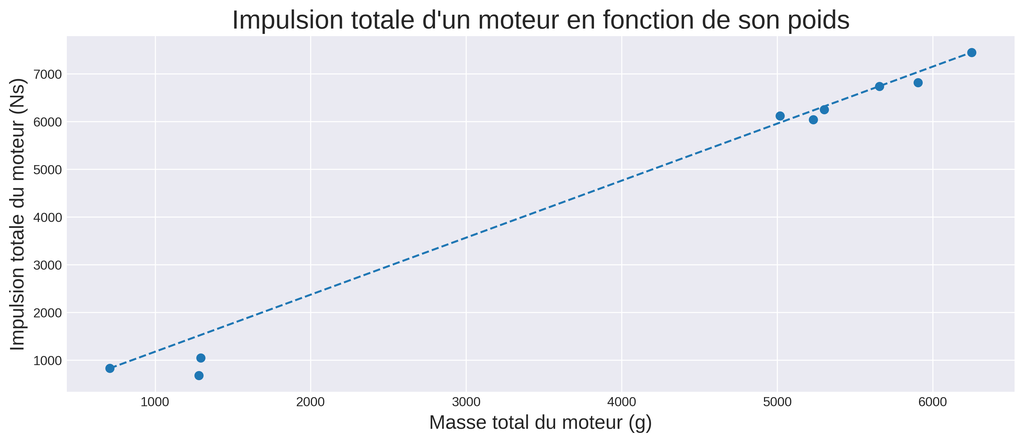

```python
import matplotlib.pyplot as plt

#création de listes contenant les valeurs du tableau
poidsmoteur = [str_en_num(fusee["Total Weight"]) for fusee in p_i_moteur]
impulsionmoteur = [str_en_num(fusee["Total Impulse"]) for fusee in p_i_moteur]
x=poidsmoteur[0], poidsmoteur[-1]
y=impulsionmoteur[0], impulsionmoteur[-1]
plt.figure(figsize=(13, 5), dpi=300)
plt.style.use('seaborn-darkgrid')
plt.scatter(poidsmoteur,impulsionmoteur)

plt.title("Impulsion totale d'un moteur en fonction de son poids", fontsize=20)
plt.xlabel('Masse total du moteur (g)', fontsize=15)
plt.ylabel('Impulsion totale du moteur (Ns)', fontsize=15)
plt.plot(x,y, linestyle="--")

plt.show()
```

Comme nous le voyons, le poids et la propulsion semblent proportionnels. En effet, l’expulsion des gaz produits par les moteurs-fusées à grande vitesse génère une poussée sur la fusée, qui est égale au produit du débit massique par la vitesse d’éjection des gaz. Le débit massique, qui correspond à la masse de combustible consommée par unité de temps, est lui-même proportionnel à la masse du totale. Ainsi, le coefficient de proportionnalité de notre graphique sera un multiple de la vitesse de la fusée.

Or, cette proportionnalité nous pose un défi: il devient plus difficile d'obtenir des moteurs plus écologiques et moins coûteux en réduisant le poids, mais qui soient tout de même efficaces. Intéressons-nous donc a la fusée qui, avec le poids le plus petit, aurait une impulsion maximale.

### Analyse

Afin de trouver ce moteur idéal, nous devons créer un dictionnaire qui contient le rapport des impulsions par le poids; plus le rapport sera elevé, plus l'impulsion est grande pour un poids plus petit, et donc plus le moteur est économe.

```python
rapp_p_i = []


for i in range(len(fdict)):
  rapport = round(str_en_num(fdict[i]["Total Impulse"])  / str_en_num(fdict[i]["Total Weight"]), 5) #on divise l'impulsion par le poids
  dico = {"Common Name": fdict[i]["Common Name"], "Rapport Impulsion-Poids": str(rapport)+" Ns/g"}
  rapp_p_i.append(dico)
```

De cette manière, nous pouvons trier les moteurs en fonction de leur performance.

```python
#tri du dico selon la valeur du rapport
rapp_p_i.sort(key = lambda x: str_en_num(x["Rapport Impulsion-Poids"]))

print("Le moteur le plus écologique et efficace est le moteur", rapp_p_i[-1]["Common Name"], "avec un rapport entre son impulsion et son poids de", rapp_p_i[-1]["Rapport Impulsion-Poids"])
print("Le moteur le moins écologique et efficace est le moteur", rapp_p_i[0]["Common Name"], "avec un rapport entre son impulsion et son poids de", rapp_p_i[0]["Rapport Impulsion-Poids"])
```

```
Le moteur le plus écologique et efficace est le moteur M3100 avec un rapport entre son impulsion et son poids de 1.21917 Ns/g
Le moteur le moins écologique et efficace est le moteur J115 avec un rapport entre son impulsion et son poids de 0.52551 Ns/g
```

Pour mieux visualiser, voici un graphe montrant le rapport de l'impulsion totale d'un moteur par son poids.

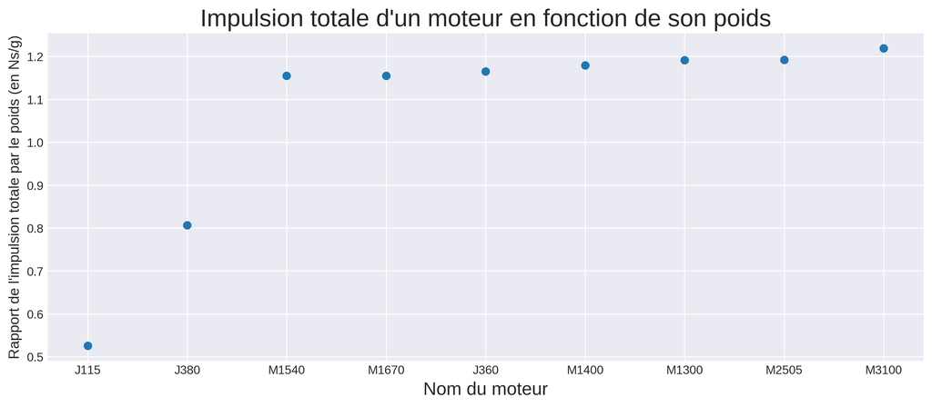

```python
import matplotlib.pyplot as plt

#création de listes contenant les valeurs du tableau
nommoteur = [(fusee["Common Name"]) for fusee in rapp_p_i]
rappmoteur = [str_en_num(fusee["Rapport Impulsion-Poids"]) for fusee in rapp_p_i]

plt.figure(figsize=(13, 5), dpi=300)

plt.scatter(nommoteur,rappmoteur)

plt.title("Impulsion totale d'un moteur en fonction de son poids", fontsize=20)
plt.xlabel('Nom du moteur', fontsize=15)
plt.ylabel("Rapport de l'impulsion totale par le poids (en Ns/g)", fontsize=12)
plt.style.use('seaborn-darkgrid')

plt.show()
```

# Conclusion